# Machine Learning: Workflow and Applications

Daniel S. Hain (dsh@business.aau.dk)

Updated September 29, 2020

# Introduction: Machine Learning with Pokémon

Back to the teens. You will work on Pokemon data. No data munging needed.

# Getting the data

# EDA & Unsupervised ML

## 1.Give a brief overview of data, what variables are there, how are the variables scaled and variation of the data columns.

| Number | Name | Type1 | Type2 | Total | HitPoints | Attack | Defense | SpecialAttack | SpecialDefense | Speed | Generation | Legendary |
| --- | --- | --- | --- | --- | --- | --- | --- | --- | --- | --- | --- | --- |
| 1 | Bulbasaur | Grass | Poison | 318 | 45 | 49 | 49 | 65 | 65 | 45 | 1 | FALSE |
| 2 | Ivysaur | Grass | Poison | 405 | 60 | 62 | 63 | 80 | 80 | 60 | 1 | FALSE |
| 3 | Venusaur | Grass | Poison | 525 | 80 | 82 | 83 | 100 | 100 | 80 | 1 | FALSE |
| 3 | VenusaurMega Venusaur | Grass | Poison | 625 | 80 | 100 | 123 | 122 | 120 | 80 | 1 | FALSE |
| 4 | Charmander | Fire | NA | 309 | 39 | 52 | 43 | 60 | 50 | 65 | 1 | FALSE |
| 5 | Charmeleon | Fire | NA | 405 | 58 | 64 | 58 | 80 | 65 | 80 | 1 | FALSE |

```
Rows: 800
Columns: 13
$ Number         <dbl> 1, 2, 3, 3, 4, 5, 6, 6, 6, 7, 8, 9, 9, 10, 11, 12, 13, 14, 15, 15, 16, 17, 18, 18, 19, 20, 21, 22, 23, 2…
$ Name           <chr> "Bulbasaur", "Ivysaur", "Venusaur", "VenusaurMega Venusaur", "Charmander", "Charmeleon", "Charizard", "C…
$ Type1          <chr> "Grass", "Grass", "Grass", "Grass", "Fire", "Fire", "Fire", "Fire", "Fire", "Water", "Water", "Water", "…
$ Type2          <chr> "Poison", "Poison", "Poison", "Poison", NA, NA, "Flying", "Dragon", "Flying", NA, NA, NA, NA, NA, NA, "F…
$ Total          <dbl> 318, 405, 525, 625, 309, 405, 534, 634, 634, 314, 405, 530, 630, 195, 205, 395, 195, 205, 395, 495, 251,…
$ HitPoints      <dbl> 45, 60, 80, 80, 39, 58, 78, 78, 78, 44, 59, 79, 79, 45, 50, 60, 40, 45, 65, 65, 40, 63, 83, 83, 30, 55, …
$ Attack         <dbl> 49, 62, 82, 100, 52, 64, 84, 130, 104, 48, 63, 83, 103, 30, 20, 45, 35, 25, 90, 150, 45, 60, 80, 80, 56,…
$ Defense        <dbl> 49, 63, 83, 123, 43, 58, 78, 111, 78, 65, 80, 100, 120, 35, 55, 50, 30, 50, 40, 40, 40, 55, 75, 80, 35, …
$ SpecialAttack  <dbl> 65, 80, 100, 122, 60, 80, 109, 130, 159, 50, 65, 85, 135, 20, 25, 90, 20, 25, 45, 15, 35, 50, 70, 135, 2…
$ SpecialDefense <dbl> 65, 80, 100, 120, 50, 65, 85, 85, 115, 64, 80, 105, 115, 20, 25, 80, 20, 25, 80, 80, 35, 50, 70, 80, 35,…
$ Speed          <dbl> 45, 60, 80, 80, 65, 80, 100, 100, 100, 43, 58, 78, 78, 45, 30, 70, 50, 35, 75, 145, 56, 71, 101, 121, 72…
$ Generation     <dbl> 1, 1, 1, 1, 1, 1, 1, 1, 1, 1, 1, 1, 1, 1, 1, 1, 1, 1, 1, 1, 1, 1, 1, 1, 1, 1, 1, 1, 1, 1, 1, 1, 1, 1, 1,…
$ Legendary      <lgl> FALSE, FALSE, FALSE, FALSE, FALSE, FALSE, FALSE, FALSE, FALSE, FALSE, FALSE, FALSE, FALSE, FALSE, FALSE,…
```

```
── Data Summary ────────────────────────
                           Values
Name                       Piped data
Number of rows             800
Number of columns          13
_______________________
Column type frequency:
  character                3
  logical                  1
  numeric                  9
________________________
Group variables            None

── Variable type: character ──────────────────────────────────────────────────────────────────────────────────────────────────────
  skim_variable n_missing complete_rate   min   max empty n_unique whitespace
1 Name                  0         1         3    25     0      800          0
2 Type1                 0         1         3     8     0       18          0
3 Type2               386         0.518     3     8     0       18          0

── Variable type: logical ────────────────────────────────────────────────────────────────────────────────────────────────────────
  skim_variable n_missing complete_rate   mean count
1 Legendary             0             1 0.0812 FAL: 735, TRU: 65

── Variable type: numeric ────────────────────────────────────────────────────────────────────────────────────────────────────────
  skim_variable  n_missing complete_rate   mean     sd    p0   p25   p50   p75  p100 hist
1 Number                 0             1 363.   208.       1 185.   364.  539.   721 ▇▇▇▇▇
2 Total                  0             1 435.   120.     180 330    450   515    780 ▃▆▇▂▁
3 HitPoints              0             1  69.3   25.5      1  50     65    80    255 ▃▇▁▁▁
4 Attack                 0             1  79.0   32.5      5  55     75   100    190 ▂▇▆▂▁
5 Defense                0             1  73.8   31.2      5  50     70    90    230 ▃▇▂▁▁
6 SpecialAttack          0             1  72.8   32.7     10  49.8   65    95    194 ▅▇▅▂▁
7 SpecialDefense         0             1  71.9   27.8     20  50     70    90    230 ▇▇▂▁▁
8 Speed                  0             1  68.3   29.1      5  45     65    90    180 ▃▇▆▁▁
9 Generation             0             1   3.32   1.66     1   2      3     5      6 ▇▅▃▅▂
```

We have 3 string variables, where one is the uniqu pokemon name, and two others it’s type. Our outcome variable `legendary` is categorical, `TRUE` if it is an legendary pokemon, `FALSE` otherwise. All other variables are numerical.

Lets briefly look at th categorical variables:

| Type1 | n |
| --- | --- |
| Water | 112 |
| Normal | 98 |
| Grass | 70 |
| Bug | 69 |
| Psychic | 57 |
| Fire | 52 |
| Electric | 44 |
| Rock | 44 |
| Dragon | 32 |
| Ghost | 32 |

[output cut: 8 more lines]

| Type2 | n |
| --- | --- |
| NA | 386 |
| Flying | 97 |
| Ground | 35 |
| Poison | 34 |
| Psychic | 33 |
| Fighting | 26 |
| Grass | 25 |
| Fairy | 23 |
| Steel | 22 |
| Dark | 20 |

[output cut: 9 more lines]

We see most pokemons have an `NA` as `Type2`, probably meening they have no second type.

We directly see some things should be changed:

1. We see an numeric `Number` variable, which is just their unique id, and not of value for the analysis, so we drop it.
2. the missing values in `Type2` probably indicate that the pokemon has no second type, should therefore not be treated as missing data
3. The `generation` variable is numeric, but probably should be interpreted as categorical.

Lets do the necessary changes upfront before investigating further.

We now can do some visualization. First my favorite standard one. Since we already know we later will be interested in legendary pokemon, we can already use the olor aestetic on this variable.

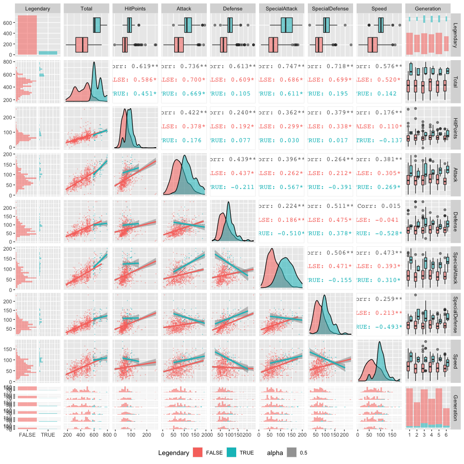

Long story short, we already see that legendary pokemon appear to be pretty much better in everything.

We can also zoom into the conditional distributions with a joyplot

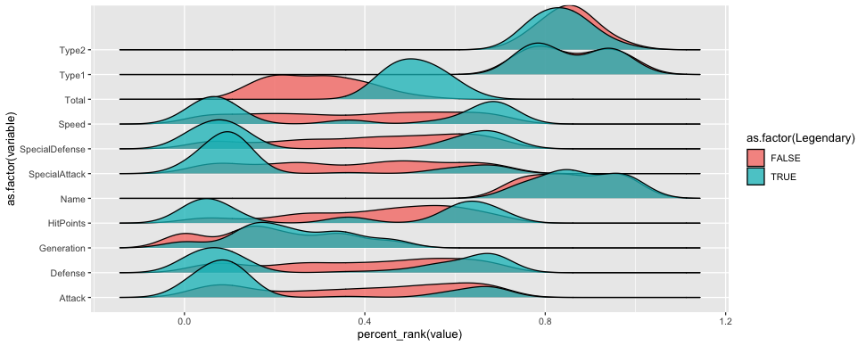

## 2. Execute a PCA analysis on all numerical variables in the dataset. Hint: Don’t forget to scale them first. Use 4 components. What is the individuel and cumulative explained variance?

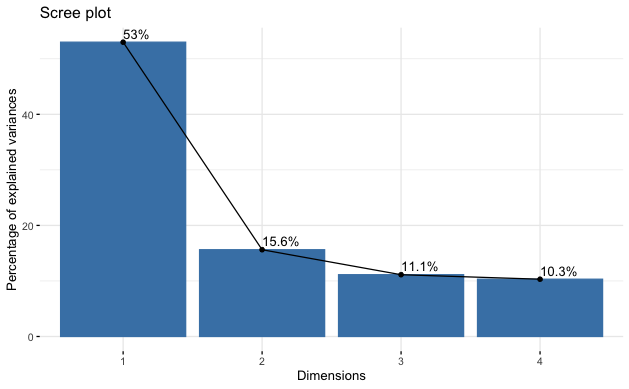

| eigenvalue | percentage of variance | cumulative percentage of variance |
| --- | --- | --- |
| 3.709472e+00 | 5.299246e+01 | 52.99246 |
| 1.093611e+00 | 1.562301e+01 | 68.61547 |
| 7.787937e-01 | 1.112562e+01 | 79.74109 |
| 7.221037e-01 | 1.031577e+01 | 90.05686 |
| 4.285601e-01 | 6.122288e+00 | 96.17915 |
| 2.674595e-01 | 3.820850e+00 | 100.00000 |
| 1.985634e-30 | 2.836620e-29 | 100.00000 |

4 Components sem to capture about 90% of the variance.

BONUS: Some visualization:

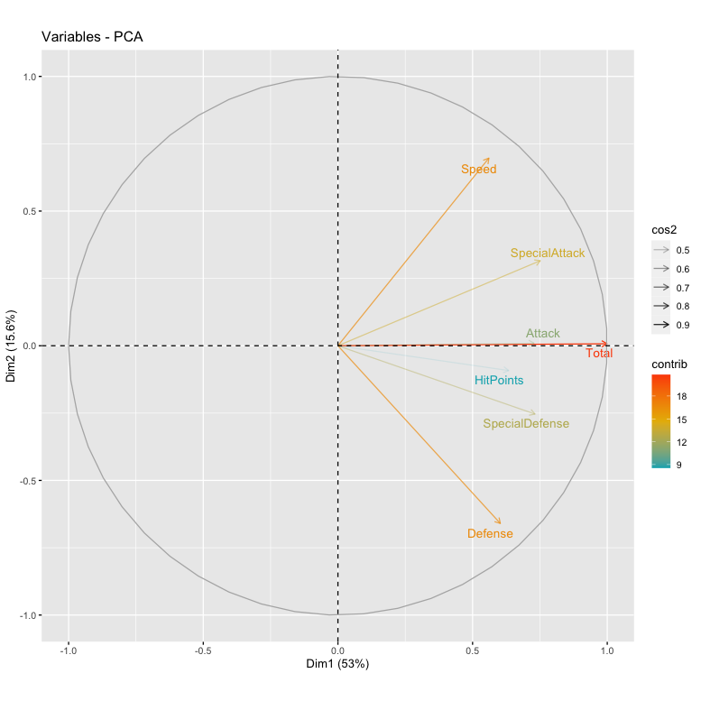

All variables pretty much point into the same direction, meaning that we mainly capture a scaling phenomenon, where variables tend to move jointly. However, we do see in the secomd component, variables seem to split between defensive and offensive attributes.

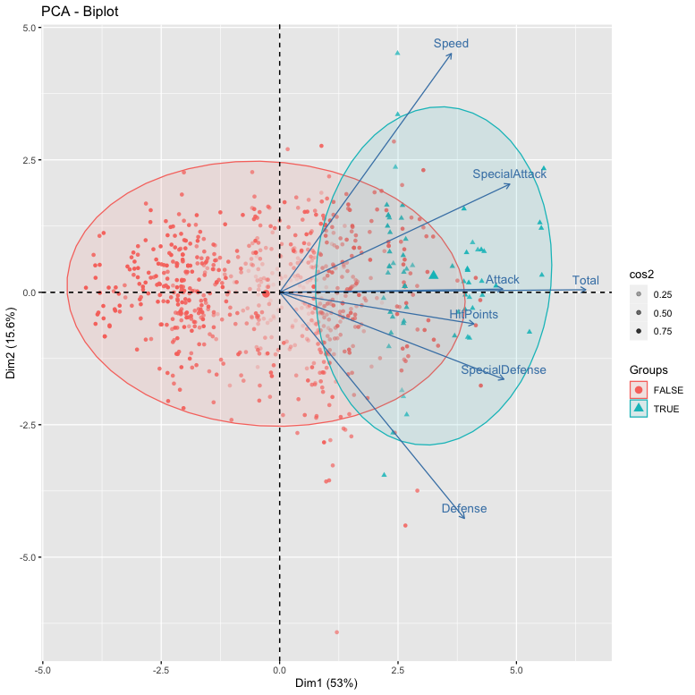

We generally see again legendary pokemon to be more in the right quadrants indicating high values in their characteristics. However, there is a large grey-zone, where the 2d projection cannot really distinguist between legendary and non-legendary pokemons.

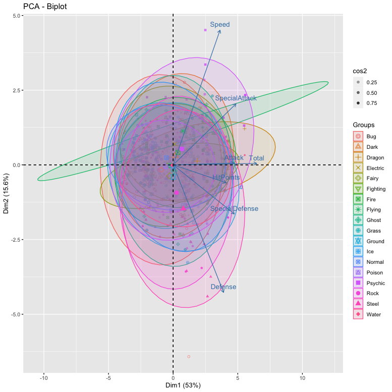

For `Type1`, we get a mess…

## Use a different dimensionality reduction method (eg. UMAP/NMF) –do the findings differ?

We ill run a simple UMAP

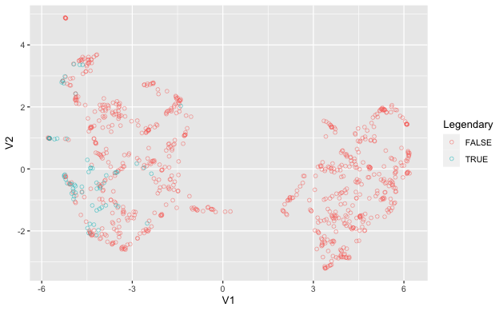

Well, UMAP seems to do a better job in sepperation high and low performing pokemons in spacw. However, we also see that only somewhat helps us to distinguish between legendary and non-legendary ones.

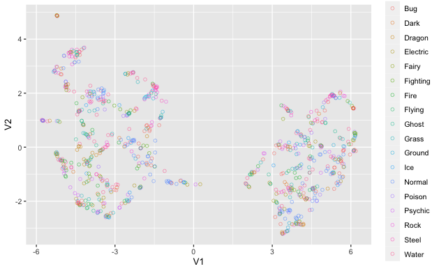

Same goes for types…

## 4. Perform a cluster analysis (KMeans) on all numerical variables (scaled & before PCA). Pick a realistic number of clusters (up to you where the large clusters remain mostly stable).

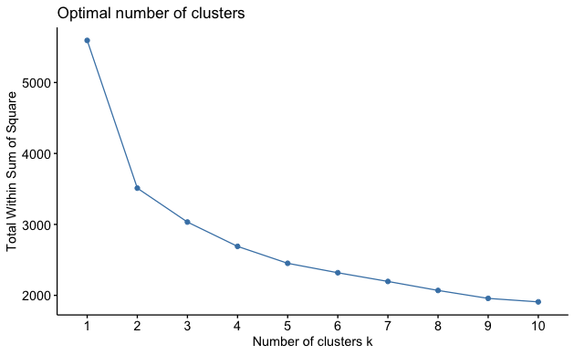

Ok,we here settle for 2 (executive decision, since we want to identify 2 distinct classes).

## 5.Visualize the first 2 principal components and color the datapoints by cluster.

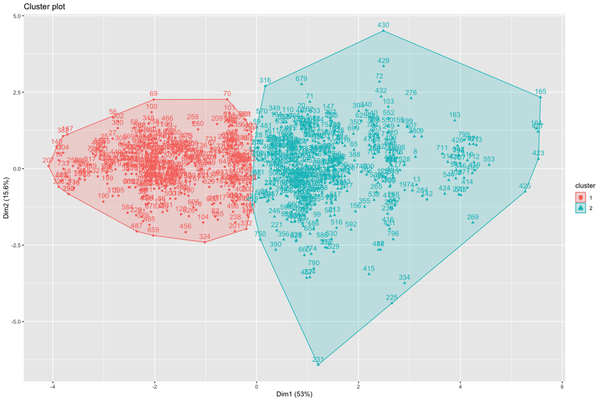

## 6.Inspect the distribution of the variable “Type1” across clusters. Does the algorithm separate the different types of pokemon?

```
            1  2
  Bug      45 24
  Dark     14 17
  Dragon    9 23
  Electric 19 25
  Fairy     9  8
  Fighting 12 15
  Fire     23 29
  Flying    1  3
  Ghost    13 19
  Grass    35 35
  Ground   16 16
  Ice      10 14
  Normal   55 43
  Poison   14 14
  Psychic  22 35
  Rock     20 24
  Steel     8 19
  Water    53 59
```

Well, not really. However, in case I would have selected more, for instance 4, clusters, I might have had a different picture.

| name | 1 | 2 |
| --- | --- | --- |
| Total | 329.07143 | 530.07820 |
| HitPoints | 54.24603 | 82.70616 |
| Attack | 58.31217 | 97.53318 |
| Defense | 56.51058 | 89.36730 |
| SpecialAttack | 52.62963 | 90.90521 |
| SpecialDefense | 53.53704 | 88.35308 |
| Speed | 53.83598 | 81.21327 |
| n | 378.00000 | 422.00000 |

As we already guessed, the 2 clusters are mainly formed by overall high or low attributes.

## 7.Perform a cluster analysis on all numerical variables scaled and AFTER dimensionality reduction and visualize the first 2 principal components.

Since we didnt specify which type of clustering, we cann also do hirarchical clustering now and use the HCPCA function for convenience.

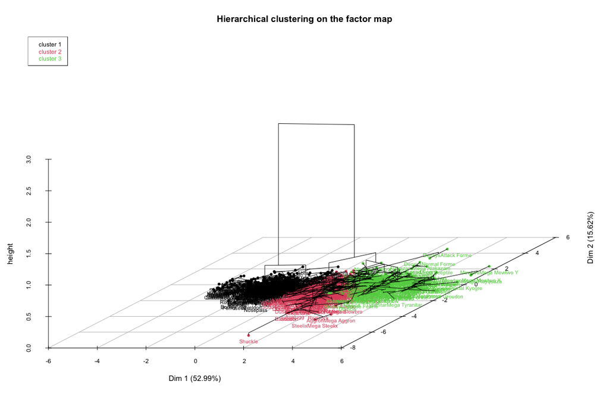

Interestingly, here we would have 3 clusters, with one in the middle.

## 8.Again, inspect the distribution of the variable “Type 1” across clusters, does it differ from the distribution before dimensionality reduction?

```
            1  2  3
  Bug      39 21  9
  Dark     11 12  8
  Dragon    5  7 20
  Electric 16  9 19
  Fairy     8  6  3
  Fighting  9 13  5
  Fire     19 11 22
  Flying    1  0  3
  Ghost    13 12  7
  Grass    28 31 11
  Ground   14 13  5
  Ice       9  9  6
  Normal   43 46  9
  Poison   14 13  1
  Psychic  19 15 23
  Rock     16 20  8
  Steel     6 15  6
  Water    44 50 18
```

Well, not reall in most cases…

# Supervised ML

Your task will be to predict the variable “legendary”, indicating if the pokemon is alegendary one or not.

## 1.Perform necessary ML preprocessing of your data if deemed necessary.

## 2.Split the data in a training (75%) and test (25%) dataset

One more thing, we have a logical outcome variable. That causes problems with some models which require factorial outcomes, so we recode it to a factor. And for sure we also drop the `Name` column which we do not want to use for the prediction.

First we split…

Now we will define a pretty standard preprocessing reciple, where we will:

1. Center and scale all numeric variables
2. Create one-hot-encodings for all categorical variables

## 3.Define a n-fold cross-validation workflow for your model testing.

From 4. we already know which models to set up, so we already set up the models. This is pretty much all only C&P from my script…

### Defining the models

#### Logistic Regression

#### Decision tree

#### Extreme Gradient Boosted Tree (XGBoost)

#### Define workflow

### Hyperparameter Tuning

#### Validation Sampling (N-fold crossvlidation)

#### Hyperparameter Tuning: Decision Tree

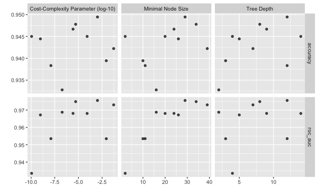

| cost_complexity | tree_depth | min_n | .config |
| --- | --- | --- | --- |
| 0.00102558 | 12 | 29 | Model07 |

| cost_complexity | tree_depth | min_n | .metric | .estimator | mean | n | std_err | .config |
| --- | --- | --- | --- | --- | --- | --- | --- | --- |
| 0.00102558 | 12 | 29 | roc_auc | binary | 0.9755408 | 9 | 0.001805544 | Model07 |

#### Hyperparameter Tuning: XGBoost

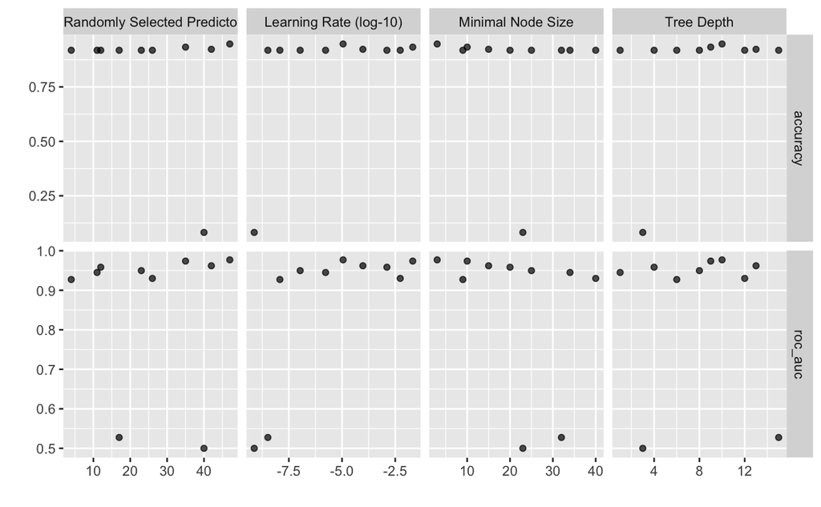

| mtry | min_n | tree_depth | learn_rate | .config |
| --- | --- | --- | --- | --- |
| 47 | 3 | 10 | 0.00001122408 | Model07 |

| mtry | min_n | tree_depth | learn_rate | .metric | .estimator | mean | n | std_err | .config |
| --- | --- | --- | --- | --- | --- | --- | --- | --- | --- |
| 47 | 3 | 10 | 0.00001122408 | roc_auc | binary | 0.9770068 | 9 | 0.001702939 | Model07 |

## 4.Fit three separate models on your training data, where you predict the“legendary” variable. Use a 1. Logistic regression, 2. Decision tree, and 3.(minimum)on adittional SML algorithm of choice to do so.

### Finalize workflow

### Fit Model on training data

### Compare performance (On training data)

| model | .estimate |
| --- | --- |
| dt | 0.9344605 |
| lg | 0.9240342 |
| xg | 0.8684766 |

## 5.Use the fitted models to predict the “legendary” variable in your test data.

That’s easy. We will jut use the `last_fit` function which fits the final model on the complete training data and predicts on the test data in one call.

| .metric | .estimator | .estimate |
| --- | --- | --- |
| accuracy | binary | 0.9350000 |
| roc_auc | binary | 0.8338995 |